# CUNY 606 Final Exam

Alex Low

December 12, 2016

## PART II

1. The mean (for x and y separately; 1 pt).

```r
options(digits=2)
data1 <- data.frame(x=c(10,8,13,9,11,14,6,4,12,7,5),
y=c(8.04,6.95,7.58,8.81,8.33,9.96,7.24,4.26,10.84,4.82,5.68))
data2 <- data.frame(x=c(10,8,13,9,11,14,6,4,12,7,5),
y=c(9.14,8.14,8.74,8.77,9.26,8.1,6.13,3.1,9.13,7.26,4.74))
data3 <- data.frame(x=c(10,8,13,9,11,14,6,4,12,7,5),
y=c(7.46,6.77,12.74,7.11,7.81,8.84,6.08,5.39,8.15,6.42,5.73))
data4 <- data.frame(x=c(8,8,8,8,8,8,8,19,8,8,8),
y=c(6.58,5.76,7.71,8.84,8.47,7.04,5.25,12.5,5.56,7.91,6.89))

mean(data1$x)
```

```
## [1] 9
```

```r
mean(data1$y)
```

```
## [1] 7.5
```

```r
mean(data2$x)
```

```
## [1] 9
```

```r
mean(data2$y)
```

```
## [1] 7.5
```

```r
mean(data3$x)
```

```
## [1] 9
```

```r
mean(data3$y)
```

```
## [1] 7.5
```

```r
mean(data4$x)
```

```
## [1] 9
```

```r
mean(data4$y)
```

```
## [1] 7.5
```

2. The median (for x and y separately; 1 pt).

```r
median(data1$x)
```

```
## [1] 9
```

```r
median(data1$y)
```

```
## [1] 7.6
```

```r
median(data2$x)
```

```
## [1] 9
```

```r
median(data2$y)
```

```
## [1] 8.1
```

```r
median(data3$x)
```

```
## [1] 9
```

```r
median(data3$y)
```

```
## [1] 7.1
```

```r
median(data4$x)
```

```
## [1] 8
```

```r
median(data4$y)
```

```
## [1] 7
```

3. The standard deviation (for x and y separately; 1 pt).

```r
sd(data1$x)
```

```
## [1] 3.3
```

```r
sd(data1$y)
```

```
## [1] 2
```

```r
sd(data2$x)
```

```
## [1] 3.3
```

```r
sd(data2$y)
```

```
## [1] 2
```

```r
sd(data3$x)
```

```
## [1] 3.3
```

```r
sd(data3$y)
```

```
## [1] 2
```

```r
sd(data4$x)
```

```
## [1] 3.3
```

```r
sd(data4$y)
```

```
## [1] 2
```

4. The correlation (1 pt).

```r
cor(data1$x,data1$y)
```

```
## [1] 0.82
```

```r
cor(data2$x,data2$y)
```

```
## [1] 0.82
```

```r
cor(data3$x,data3$y)
```

```
## [1] 0.82
```

```r
cor(data4$x,data4$y)
```

```
## [1] 0.82
```

5. Linear regression equation (2 pts).
6. R-Squared (2 pts).

```r
library(dplyr)
summary(lm(data1$y ~ data1$x))
```

```
##
## Call:
## lm(formula = data1$y ~ data1$x)
##
## Residuals:
##     Min      1Q  Median      3Q     Max
## -1.9213 -0.4558 -0.0414  0.7094  1.8388
##
## Coefficients:
##             Estimate Std. Error t value Pr(>|t|)
## (Intercept)    3.000      1.125    2.67   0.0257 *
## data1$x        0.500      0.118    4.24   0.0022 **
## ---
## Signif. codes:  0 '***' 0.001 '**' 0.01 '*' 0.05 '.' 0.1 ' ' 1
##
## Residual standard error: 1.2 on 9 degrees of freedom
## Multiple R-squared:  0.667,  Adjusted R-squared:  0.629
## F-statistic:   18 on 1 and 9 DF,  p-value: 0.00217
```

```r
summary(lm(data2$y ~ data2$x))
```

```
##
## Call:
## lm(formula = data2$y ~ data2$x)
##
## Residuals:
##    Min     1Q Median     3Q    Max
## -1.901 -0.761  0.129  0.949  1.269
##
## Coefficients:
##             Estimate Std. Error t value Pr(>|t|)
## (Intercept)    3.001      1.125    2.67   0.0258 *
## data2$x        0.500      0.118    4.24   0.0022 **
## ---
## Signif. codes:  0 '***' 0.001 '**' 0.01 '*' 0.05 '.' 0.1 ' ' 1
##
## Residual standard error: 1.2 on 9 degrees of freedom
## Multiple R-squared:  0.666,  Adjusted R-squared:  0.629
## F-statistic:   18 on 1 and 9 DF,  p-value: 0.00218
```

```r
summary(lm(data3$y ~ data3$x))
```

```
##
## Call:
## lm(formula = data3$y ~ data3$x)
##
## Residuals:
##    Min     1Q Median     3Q    Max
## -1.159 -0.615 -0.230  0.154  3.241
##
## Coefficients:
##             Estimate Std. Error t value Pr(>|t|)
## (Intercept)    3.002      1.124    2.67   0.0256 *
## data3$x        0.500      0.118    4.24   0.0022 **
## ---
## Signif. codes:  0 '***' 0.001 '**' 0.01 '*' 0.05 '.' 0.1 ' ' 1
##
## Residual standard error: 1.2 on 9 degrees of freedom
## Multiple R-squared:  0.666,  Adjusted R-squared:  0.629
## F-statistic:   18 on 1 and 9 DF,  p-value: 0.00218
```

```r
summary(lm(data4$y ~ data4$x))
```

```
##
## Call:
## lm(formula = data4$y ~ data4$x)
##
## Residuals:
##    Min     1Q Median     3Q    Max
## -1.751 -0.831  0.000  0.809  1.839
##
## Coefficients:
##             Estimate Std. Error t value Pr(>|t|)
## (Intercept)    3.002      1.124    2.67   0.0256 *
## data4$x        0.500      0.118    4.24   0.0022 **
## ---
## Signif. codes:  0 '***' 0.001 '**' 0.01 '*' 0.05 '.' 0.1 ' ' 1
##
## Residual standard error: 1.2 on 9 degrees of freedom
## Multiple R-squared:  0.667,  Adjusted R-squared:  0.63
## F-statistic:   18 on 1 and 9 DF,  p-value: 0.00216
```

Data set 1 Y = 3 + 0.5x R-squared: 0.667

Data set 2 Y = 3.001 + 0.5x R-squared: 0.666

Data set 3 Y = 3.002 + 0.5x R-squared: 0.666

Data set 4 Y = 3.002 + 0.5x R-squared: 0.667

For each pair, is it appropriate to estimate a linear regression model? Why or why not? Be speci???c as to why for each pair and include appropriate plots!

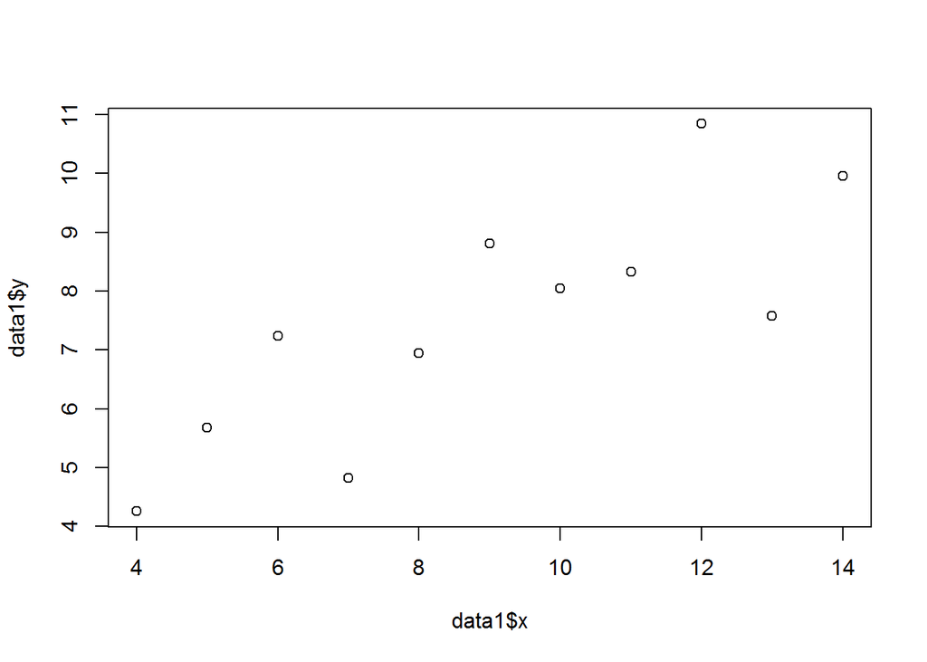

```r
d1 <- lm(data1$y ~ data1$x)

#Linearity
#Constant variability
plot(data1$y ~ data1$x)
```

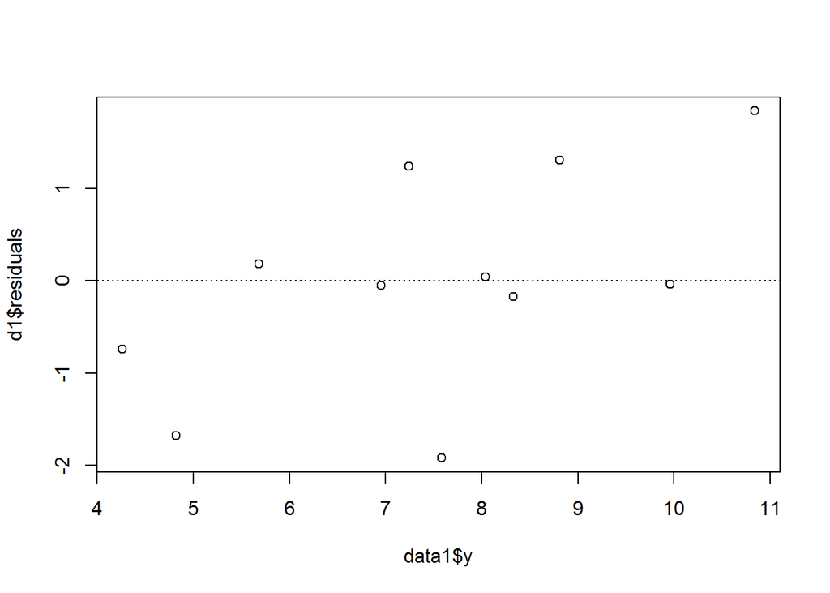

```r
plot(d1$residuals ~ data1$y)
abline(h = 0, lty = 3)
```

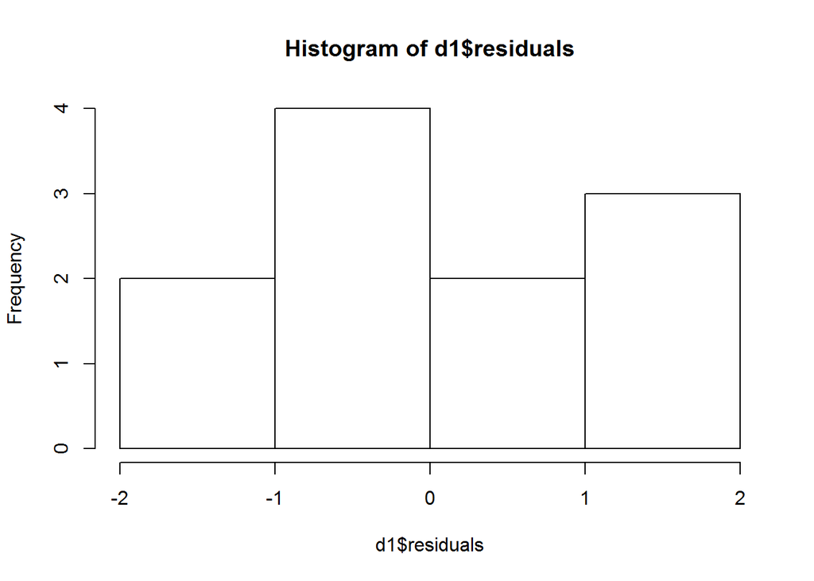

```r
#Nearly normal residuals
hist(d1$residuals)
```

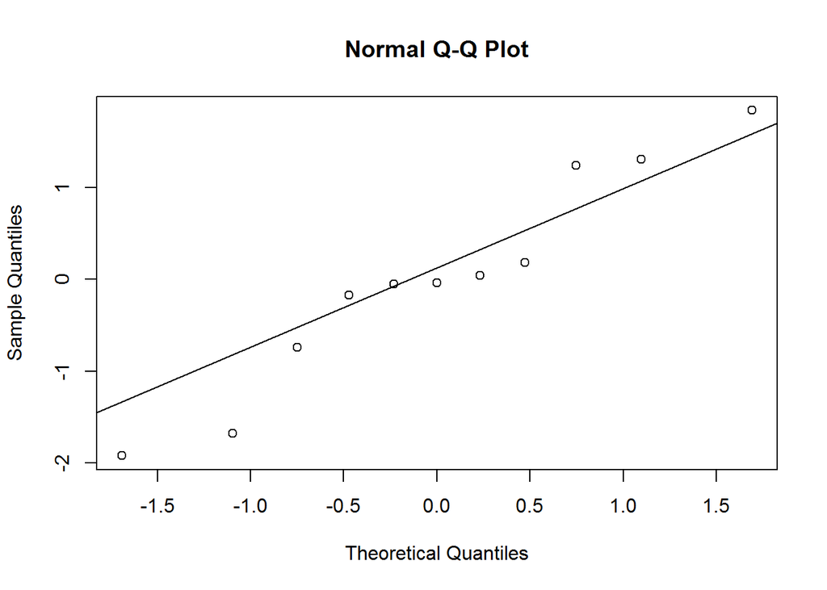

```r
qqnorm(d1$residuals)
qqline(d1$residuals)
```

Data 1: The relationship between the variables appears to be linear and there is relatively constant variability. The residuals are not clearly normal acccording to the histogram but the QQ plot looks ok. I therefore conlude that it is appropriate to estimate a linear regression model.

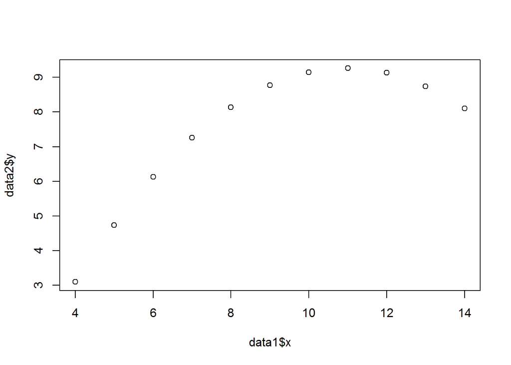

```r
d2 <- lm(data1$y ~ data1$x)

#Linearity
#Constant variability
plot(data2$y ~ data1$x)
```

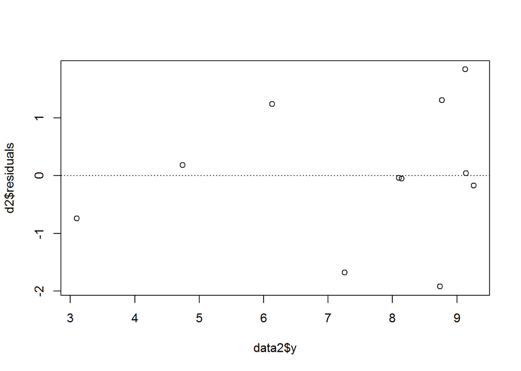

```r
plot(d2$residuals ~ data2$y)
abline(h = 0, lty = 3)
```

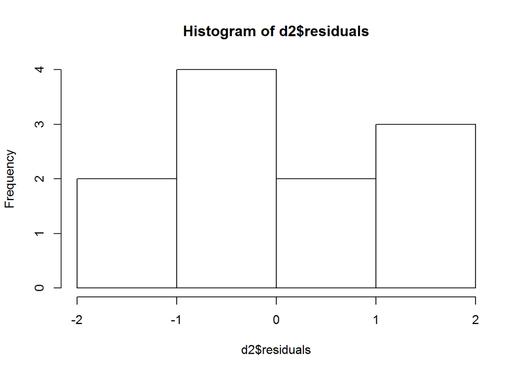

```r
#Nearly normal residuals
hist(d2$residuals)
```

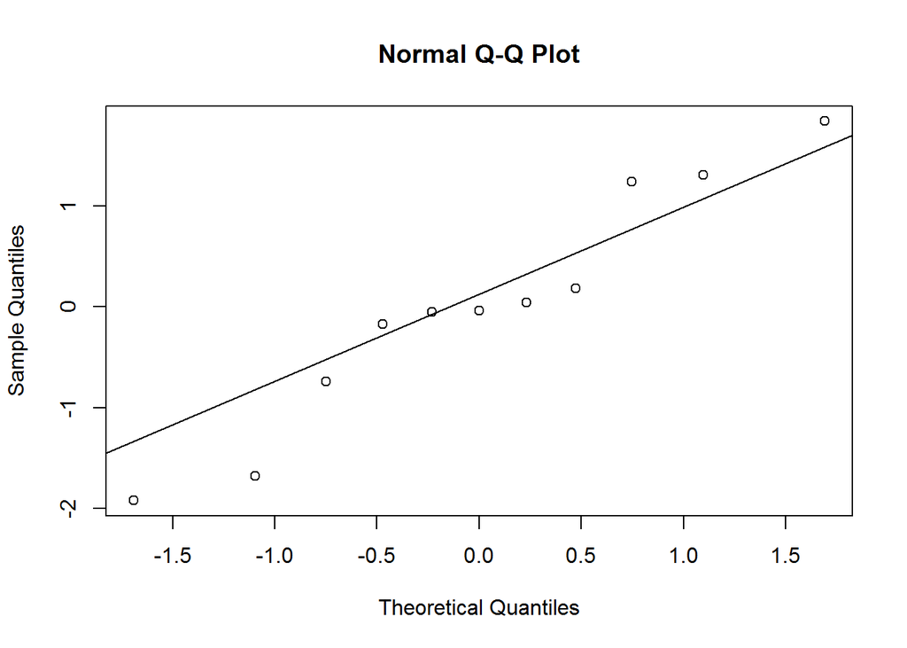

```r
qqnorm(d2$residuals)
qqline(d2$residuals)
```

Data 2: The relationship between the variables does not appear to be linear and there is not constant variability. Therefore I do not believe it is appropriate to estimate a linear regression model for this data set.

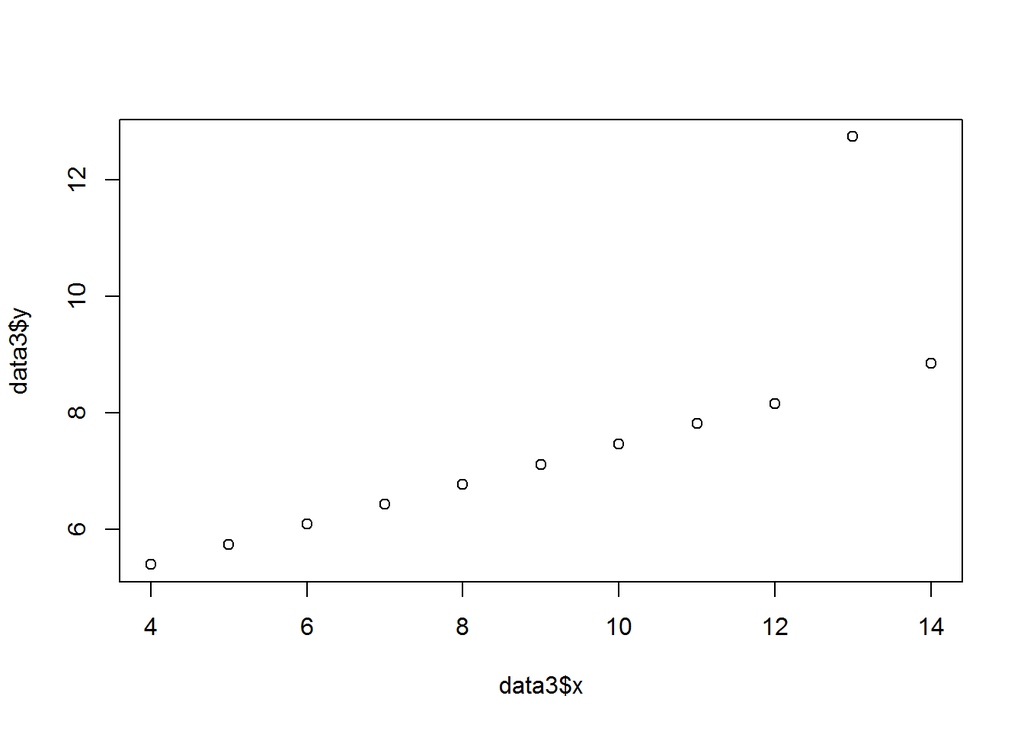

```r
d3 <- lm(data3$y ~ data3$x)

#Linearity
#Constant variability
plot(data3$y ~ data3$x)
```